# Lab 2 - Meet R Markdown

Benson Truong

10/7/2019

Here is some text! Hooray!

# Giant Header

## A little smaller header

### Even smaller…

##### A little header

We can make a bulleted list:

- first item
- second item
- third item
1. Here is a numbered list
2. Second item
3. Third item

We can make things *italicized* or **bold**

We can make superscripts<sup>UP</sup> and subscripts-DOWN-

I can add a hyperlink: http://ucsb.edu/

Or I can add linked text [like this!](http://ucsb.edu/)

### Adding code in R Markdown

For any active code, we need to add it within a code chunk (“crtl”+“alt”+“I”):

### Read in some data

Read in the wb_env.csv

Gather the wb_env data into long format using pivot_longer()

Now a bit more cleaning(make all columns lower snakecase, remove x64, change year to values instead of character): -To check if variable(year) is a “character” or “numeric”: class(wb_df$year)

Now I’m going to do some filtering and subsetting to only look at CO2 kTons "CO2 emissions(kt): -To find # of unique values/observations: unique(wb_df$indicator_name)

Now, I’m going to read in the country_list.csv data:

Now I’m going to join the country list and wb_co2 together using inner_join()

Use the head() function to only keep the top 20 CO2 emitters (total CO2 (kt) from 2008 = 2018)

Some options for exploratory graphs:

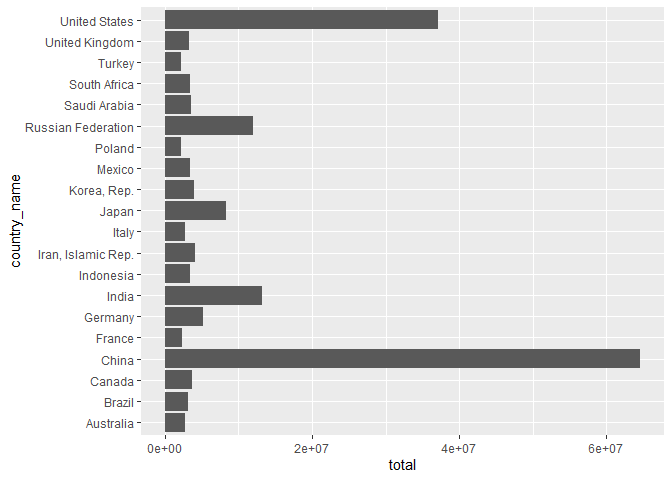

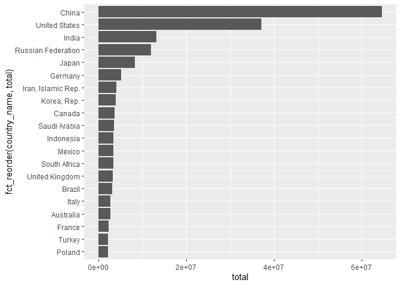

A slightly more customized graph:

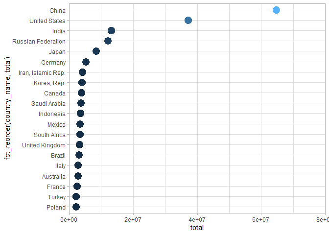